# Pivot Table

David Gerbing

## Overview

### Descriptive Statistics

Descriptive summarize characteristics of the sample data values for one or more variables. The **lessR** `pivot()` function serves as a single source for a wide variety and types of descriptive statistics for one or more variables communicated in the form of a *pivot table*. Compute statistics either for the entire data set at once or separately for different groups of data.

> *Aggregation*: From the values of categorical variables, form groups of data and then compute one or more statistics for each group.

As an example of aggregation, compute the mean Years worked for each combination of the levels of *Gender* and *Dept* (department) of employment. To introduce the ease of use of `pivot()`, and to provide context for the following discussion, the function call listed below includes the parameter names (in red) for emphasis. However, if the parameters are entered in this order, listing their names is not necessary. Enter multiple values, such as for *Gender* and *Dept* as an R vector, defined such as with the base R combine `c()` function. The output of the analysis is shown later.

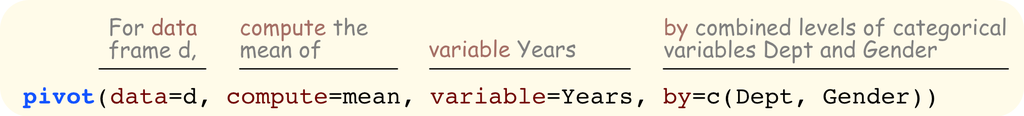

The `pivot()` function computes statistics for three classes of variables:

- Numerical variables that represent continuity such as time, money, and weight.
- Numerical variables that represent ordered categories, such as Likert scale responses Strongly Disagree to Strongly Agree on a 5-pt scale coded 1 to 5.
- Non-numerical categorical variables such as Gender encoded as Male, Female, and Other, or coded as integers but without numerical properties, such as 0, 1, and 2 for three values of Gender.

Any function that processes a single vector of data, such as a column of data values for a variable in a data frame, and outputs a single computed value, the statistic, can be passed to `pivot()`. The phrase “any function” is quite general, including any function in any active package as well as user-defined functions that satisfy these criteria. The function accessed by `pivot()` can be one of the many available R statistical functions that summarize data, including those in the following table.

| Statistic | Meaning |
| --- | --- |
| `sum` | sum |
| `mean` | arithmetic mean |
| `median` | median |
| `min` | minimum |
| `max` | maximum |
| `sd` | standard deviation |
| `var` | variance |
| `skew` | skew |
| `kurtosis` | kurtosis |
| `IQR` | inter-quartile range |
| `mad` | mean absolute deviation |

The statistics `skew` and `kurtosis` have no counterparts in base R, so are provided by **lessR**. Computations of all other statistics follow from base R functions.

The `quantile` and `table` computations return multiple values. They are accessible to `pivot()` only because of internal programming that recognizes these functions and then processes the resulting multiple output values.

| Statistic | Meaning |
| --- | --- |
| `quantile` | min, quantiles, max |
| `table` | cell counts or proportions |

The default quantiles for `quantile` are quartiles. Specify a custom number of quantiles with the `q_num` parameter other than 4 for quartiles.

The `table` computation applies to an aggregated variable that consists of discrete categories, such as the numbers 1 through 5 for responses to a 5-pt Likert scale. The result is a table of frequencies or proportions, referred to for two or more variables as either a contingency table, a cross-tabulation table, or a joint frequency distribution. Only the `table` computation applies to non-numeric as well as numeric variables, though only meaningful if the aggregated variable consists of a relatively small set of discrete values, character strings or numeric.

When calculating a statistic, the analyst should be aware of the present and missing (not available or `NA`) data that underlies the computed statistic. Accordingly, `pivot()` by default provides the sample size information for each calculation. Turn off the display of information by setting the `show_n` parameter to `FALSE`.

### Parameters

The following `pivot()` parameters specify the data, one or more statistics to compute for the aggregation, the variables over which to aggregate, and the corresponding groups that contain the aggregated values. The first three parameter values listed below are required: the data frame, at least one statistic to compute, and at least one variable for which to compute the statistic(s).

1. `data`: The data frame that includes the variables of interest.
2. `compute`: One or more functions that specify the corresponding statistics to compute.
3. `variable`: One or more numerical variables to summarize, either by aggregation over groups or the entire sample as a single group.
4. `by`: Specify the optional aggregation according to the categorical variable(s) that define the groups.
5. `by_cols`: The optional categorical variable(s) that define the groups or cells for which to compute the aggregated values, listed as columns in a two-dimensional table instead of a data frame.

For the given `data`, `compute` at least one statistic for at least one `variable`. If aggregating across groups, compute the statistic(s) for each group specified by `by` and possibly `by_cols`.

If no categorical (`by`) variables are selected to define groups, then one or more statistics are computed over multiple variables over the entire data table defined as a single group. For categorical (grouping) variables, defined with `by` and optionally `by_cols`, choose to either `compute` multiple statistics or multiple `variable`(s), but not both.

> Select any two of the three possibilities for multiple parameter values: Multiple compute functions, multiple variables over which to compute, and multiple categorical variables by which to define groups for aggregation.

Specify multiple descriptive statistics to compute, multiple values for which to do the computation, and multiple categorical variables to define groups as vectors such as with the base R `c()` function.

### Output

The default output of `pivot()` is a data frame, a two-dimensional table, rows and columns. The output table can have multiple rows and multiple columns according to the choice of parameter values. For each numerical variable in the analysis, `pivot()` displays both the corresponding sample size as `n_` and amount of missing or not available data as `na_`. Prevent displaying sample size information by setting parameter `show_n` to `FALSE`.

The output is structured according to the following.

- The default form is a data frame with the categorical variables in the analysis listed as columns first, followed by the numerical variables, ready for input into data analysis procedures. Each row of the output data frame consists of the corresponding values for the levels of the categorical variables and the corresponding values of any aggregated statistics.
- If one or two categorical variables are specified with the `by_cols` parameter, the output is a table instead of a data frame with the specified categorical variables in the columns, amenable for viewing.
- If there is no aggregation specified, no `by` variables, the corresponding statistics are computed over the entire input data frame defined as a single group.
- There may be many variables to summarize, such as all the items on a multi-item scale from a survey analysis, so the output is a data frame. The variable names have appended an indication of the corresponding computed statistic and the rows defined by the combinations of levels of the `by` variables.

## Output as a Long-Form Data Frame

To illustrate, use the 37-row Employee data set included with **lessR**, here read into the *d* data frame.

```r
d <- Read("Employee")
```

Two categorical variables in the *d* data frame are *Dept* and *Gender*, encoded as character strings. Continuous variables include *Years* employed at the company and annual *Salary*.

### Multiple Grouping Variables

This example does the analysis previously illustrated. The name of the computed mean of *Years* by default is *Years_mean*. With no `by_cols` variables, the output of `pivot()` is a data frame of the aggregated variables. Optionally save this output for further analysis, as the data frame *a* in this example.

```r
a <- pivot(data=d, compute=mean, variable=Years, by=c(Dept, Gender))
a
```

```
##    Dept Gender Years_n Years_na Years_mean
## 1  ACCT      M       2        0      7.000
## 2  ADMN      M       2        0     15.500
## 3  FINC      M       3        0     11.333
## 4  MKTG      M       1        0     18.000
## 5  SALE      M       9        1     12.333
## 6  <NA>      M       0        0         NA
## 7  ACCT      W       3        0      4.667
## 8  ADMN      W       4        0      7.500
## 9  FINC      W       1        0      7.000
## 10 MKTG      W       5        0      8.200
## 11 SALE      W       5        0      6.600
## 12 <NA>      W       1        0      5.000
```

Using the **lessR** function `Read()`, can read the original data table from which the pivot table was constructed, such as in the form of an Excel worksheet. For many analyses, easier to read the Excel data into R and do the analysis in R than remain in Excel. The result can also be written back into an Excel file with the **lessR** function `Write()`.

In this example, create an Excel file called *MyPivotTable.xlsx* from the pivot table stored in the *a* data frame. To avoid creating this file, the function call is commented out with the `#` symbol in the first column.

```r
#Write("MyPivotTable", data=a, format="Excel")
```

The abbreviation `wrt_x()` for the function name simplifies the preceding expression for writing to an Excel file, with the `format` parameter dropped.

### Aggregate with Multiple Statistics

```r
pivot(d, c(mean, median, sd, IQR), Salary, Dept)
```

```
##   Dept Salary_n Salary_na Salary_mean Salary_mdn Salary_sd Salary_IQR
## 1 ACCT        5         0    61792.78   69547.60  12774.61   21379.23
## 2 ADMN        6         0    81277.12   71058.60  27585.15   36120.57
## 3 FINC        4         0    69010.68   61937.62  17852.50   16034.81
## 4 MKTG        6         0    70257.13   61658.99  19869.81   26085.69
## 5 SALE       15         0    78830.07   77714.85  23476.84   28810.28
## 6 <NA>        1         0    53772.58   53772.58        NA       0.00
```

Also have available two functions provided by **lessR** that are not part of base R: `skew()` and `kurtosis()`.

```r
pivot(d, c(mean,sd,skew,kurtosis), Salary, Dept, digits_d=3)
```

```
##   Dept Salary_n Salary_na Salary_mean Salary_sd Salary_skew Salary_kurt
## 1 ACCT        5         0    61792.78  12774.61      -0.623      -3.032
## 2 ADMN        6         0    81277.12  27585.15       0.835      -1.185
## 3 FINC        4         0    69010.68  17852.50       1.689       2.752
## 4 MKTG        6         0    70257.13  19869.81       0.859      -1.458
## 5 SALE       15         0    78830.07  23476.84       0.863       0.856
## 6 <NA>        1         0    53772.58        NA          NA          NA
```

Can also customize the variable names of the aggregated statistics with the `out_names` parameter. Here calculate the mean and median *Salary* for each group defined by each combination of levels for *Gender* and *Dept*.

```r
pivot(d, c(mean, median), Salary, c(Gender,Dept), out_names=c("MeanSalary", "MedianSalary"))
```

```
##    Gender Dept Salary_n Salary_na MeanSalary MedianSalary
## 1       M ACCT        2         0   59626.19     59626.19
## 2       W ACCT        3         0   63237.16     71084.02
## 3       M ADMN        2         0   80963.35     80963.35
## 4       W ADMN        4         0   81434.00     71058.60
## 5       M FINC        3         0   72967.60     66312.89
## 6       W FINC        1         0   57139.90     57139.90
## 7       M MKTG        1         0   99062.66     99062.66
## 8       W MKTG        5         0   64496.02     61356.69
## 9       M SALE       10         0   86150.97     82442.74
## 10      W SALE        5         0   64188.25     56508.32
## 11      M <NA>        0         0         NA           NA
## 12      W <NA>        1         0   53772.58     53772.58
```

### Aggregate Multiple Variables

The `pivot()` function can aggregate over multiple `variables`. Here, aggregate *Years* and *Salary*. Round the numerical aggregated results to the nearest integer with the `digits_d` parameter, which specifies the number of decimal digits in the output. Different variables can have different amounts of missing data, so the sample size, *n*, and number missing, the number of values Not Available, *na*, are listed separately for each aggregated variable.

```r
pivot(d, mean, c(Years, Salary), c(Dept, Gender), digits_d=0)
```

```
##    Dept Gender Years_n Years_na Years_mean Salary_n Salary_na Salary_mean
## 1  ACCT      M       2        0          7        2         0       59626
## 2  ADMN      M       2        0         16        2         0       80963
## 3  FINC      M       3        0         11        3         0       72968
## 4  MKTG      M       1        0         18        1         0       99063
## 5  SALE      M       9        1         12       10         0       86151
## 6  <NA>      M       0        0         NA        0         0          NA
## 7  ACCT      W       3        0          5        3         0       63237
## 8  ADMN      W       4        0          8        4         0       81434
## 9  FINC      W       1        0          7        1         0       57140
## 10 MKTG      W       5        0          8        5         0       64496
## 11 SALE      W       5        0          7        5         0       64188
## 12 <NA>      W       1        0          5        1         0       53773
```

Turn off the display of the sample size and number of missing values for each group by setting the parameter `show_n` to `FALSE`.

```r
pivot(d, mean, c(Years, Salary), Dept, digits_d=2, show_n=FALSE)
```

```
##   Dept Years_mean Salary_mean
## 1 ACCT       5.60    61792.78
## 2 ADMN      10.17    81277.12
## 3 FINC      10.25    69010.68
## 4 MKTG       9.83    70257.13
## 5 SALE      10.29    78830.06
## 6 <NA>       5.00    53772.58
```

### Compute over All Data

Aggregation computes one or more statistics for one or more variables across different groups. Or, compute the variables for each statistic for *all* the data. To compute over all the rows of data, do not specify groups, that is, drop the `by` parameter.

Get the grand mean of Years, that is, for all the data.

```r
pivot(d, mean, Years)
```

```
##   n na  mean
##  36  1 9.389
```

Get the grand mean of Years and Salary. Specify custom names for the results.

```r
pivot(d, mean, c(Years, Salary), digits_d=2, out_names=c("MeanYear", "MeanSalary"))
```

```
##  Years_n Years_na MeanYear Salary_n Salary_na MeanSalary
##       36        1     9.39       37         0   73795.56
```

Consider an example with more variables. Analyze the 6-pt Likert scale responses to the Mach IV scale that assesses Machiavellianism. Items are scored from 0 to 5, Strongly Disagree to Strongly Agree. The data are included with **lessR** as the *Mach4* data file. Suppress output when reading by setting `quiet` to `TRUE`.

```r
d <- Read("Mach4", quiet=TRUE)
```

Calculate the mean, standard deviation, skew, and kurtosis for all of the data for each of the 20 items on the scale. With this specification, the form of a data frame is statistics in the columns and the variables in the rows. The result are the specified summary statistics for the specified variables over the entire data set.

```r
pivot(d, c(mean,sd,skew,kurtosis), m01:m20)
```

```
##       n na  mean    sd  skew kurtosis
## m01 351  0 1.279 1.286  0.98     0.36
## m02 351  0 1.746 1.480  0.48    -0.78
## m03 351  0 2.900 1.450 -0.36    -0.83
## m04 351  0 3.339 1.174 -0.85     0.46
## m05 351  0 2.234 1.583  0.08    -1.09
## m06 351  0 3.074 1.478 -0.45    -0.92
## m07 351  0 2.775 1.473 -0.07    -1.15
## m08 351  0 2.100 1.456  0.13    -1.08
## m09 351  0 4.225 1.155 -1.74     2.74
## m10 351  0 3.991 1.138 -1.15     0.93
## m11 351  0 1.641 1.395  0.64    -0.39
## m12 351  0 1.801 1.625  0.42    -1.12
## m13 351  0 1.385 1.368  0.84    -0.13
## m14 351  0 1.954 1.304  0.20    -0.92
## m15 351  0 2.123 1.367 -0.09    -0.99
## m16 351  0 2.177 1.782  0.24    -1.36
## m17 351  0 2.407 1.604  0.09    -1.14
## m18 351  0 2.915 1.326 -0.56    -0.33
## m19 351  0 1.157 1.425  1.29     0.87
## m20 351  0 0.895 1.351  1.50     1.22
```

### Frequency Tables

Aggregating a statistical computation of a continuous variable over groups with `pivot()`, such as computing the mean for each combination of *Dept* and *Gender*, by default includes the tabulation for each group (cell). A tabulation can be requested with no analysis of a variable, instead only a counting of the available levels of the specified categorical variables.

The `table` value of the `compute` parameter specifies to compute the frequency table for a categorical aggregated `variable` across all combinations of the `by` variables. Specify one categorical `variable` with the remaining categorical variables specified with the `by` parameter. Missing values for each combination of the levels of the grouping variables are displayed.

Begin with a one-way frequency table computed over the entire data set.

```r
pivot(d, table, m06)
```

```
##   m06   n Prop
## 1   0  18 0.05
## 2   1  47 0.13
## 3   2  63 0.18
## 4   3  44 0.13
## 5   4 121 0.34
## 6   5  58 0.17
```

In this example, compute a two-way cross-tabulation table with the levels of `variable` *m06* as columns and the levels of the `by` categorical variable *m07* as rows.

```r
pivot(d, table, m06, m07)
```

```
##   m07 0  1  2  3  4  5  n _na
## 1   0 4  3  2  3  3  2 17   0
## 2   1 7 24  7  6 18  2 64   0
## 3   2 4 14 30 13 24  2 87   0
## 4   3 2  1 10 16 12  2 43   0
## 5   4 0  3 13  5 56 16 93   0
## 6   5 1  2  1  1  8 34 47   0
```

To output the data in long form, one tabulation per row, set the `table_long` parameter to TRUE.

If interested in the inferential analysis of the cross-tabulation table, access the **lessR** function `Prop_test()` to obtain both the descriptive and inferential results, though limited to a one- or two-way table.

The default data table is *d*, but included explicitly in the following example to illustrate the `data` parameter.

```r
Prop_test(m06, by=m07, data=d)
```

```
## variable: m06
## by: m07
##
## <<< Pearson's Chi-squared test
##
## --- Description
##
##      m06
## m07     0   1   2   3   4   5 Sum
##   0     4   3   2   3   3   2  17
##   1     7  24   7   6  18   2  64
##   2     4  14  30  13  24   2  87
##   3     2   1  10  16  12   2  43
##   4     0   3  13   5  56  16  93
##   5     1   2   1   1   8  34  47
##   Sum  18  47  63  44 121  58 351
##
##  Cramer's V: 0.380
##
##  Row Col Observed Expected Residual Stnd Res
##    1   1        4    0.872    3.128    3.526
##    1   2        3    2.276    0.724    0.528
##    1   3        2    3.051   -1.051   -0.681
##    1   4        3    2.131    0.869    0.652
##    1   5        3    5.860   -2.860   -1.496
##    1   6        2    2.809   -0.809   -0.542
##    2   1        7    3.282    3.718    2.330
##    2   2       24    8.570   15.430    6.263
##    2   3        7   11.487   -4.487   -1.616
##    2   4        6    8.023   -2.023   -0.844
##    2   5       18   22.063   -4.063   -1.182
##    2   6        2   10.575   -8.575   -3.192
##    3   1        4    4.462   -0.462   -0.259
##    3   2       14   11.650    2.350    0.853
##    3   3       30   15.615   14.385    4.634
##    3   4       13   10.906    2.094    0.782
##    3   5       24   29.991   -5.991   -1.558
##    3   6        2   14.376  -12.376   -4.119
##    4   1        2    2.205   -0.205   -0.151
##    4   2        1    5.758   -4.758   -2.274
##    4   3       10    7.718    2.282    0.968
##    4   4       16    5.390   10.610    5.216
##    4   5       12   14.823   -2.823   -0.967
##    4   6        2    7.105   -5.105   -2.238
##    5   1        0    4.769   -4.769   -2.615
##    5   2        3   12.453   -9.453   -3.357
##    5   3       13   16.692   -3.692   -1.164
##    5   4        5   11.658   -6.658   -2.432
##    5   5       56   32.060   23.940    6.092
##    5   6       16   15.368    0.632    0.206
##    6   1        1    2.410   -1.410   -1.002
##    6   2        2    6.293   -4.293   -1.976
##    6   3        1    8.436   -7.436   -3.037
##    6   4        1    5.892   -4.892   -2.315
##    6   5        8   16.202   -8.202   -2.705
##    6   6       34    7.766   26.234   11.071
##
## --- Inference
##
## Chi-square statistic: 253.103
## Degrees of freedom: 25
## Hypothesis test of equal population proportions: p-value = 0.000
```

Can also aggregate other statistics simultaneously in addition to the frequency table, though, of course, only meaningful if the aggregated variable is numerical. Here, create a 3-way cross-tabulation table with responses to `variable` *m06* in the column and responses to `by` variables *m07* and *m10* in the rows, plus the mean and standard deviation of each combination of *m07* and *m10* across levels of *m06*.

```r
pivot(d, c(mean,sd,table), m06, c(m07, m10))
```

```
##    m07 m10 m06_n m06_na m06_mean m06_sd 2 3  4  5  n _na
## 1    0   0     1      0    0.000     NA 0 0  0  0  1   0
## 2    1   0     1      0    1.000     NA 0 0  0  0  1   0
## 3    2   0    NA      0       NA     NA 0 0  0  0  0   0
## 4    3   0     1      0    2.000     NA 1 0  0  0  1   0
## 5    4   0     1      0    2.000     NA 1 0  0  0  1   0
## 6    5   0    NA      0       NA     NA 0 0  0  0  0   0
## 7    0   1    NA      0       NA     NA 0 0  0  0  0   0
## 8    1   1     4      0    0.750  0.500 0 0  0  0  4   0
## 9    2   1     2      0    1.500  0.707 1 0  0  0  2   0
## 10   3   1     1      0    2.000     NA 1 0  0  0  1   0
## 11   4   1    NA      0       NA     NA 0 0  0  0  0   0
## 12   5   1    NA      0       NA     NA 0 0  0  0  0   0
## 13   0   2     2      0    2.000  1.414 0 1  0  0  2   0
## 14   1   2     9      0    1.222  1.202 1 0  1  0  9   0
```

[output cut: 22 more lines]

Can also express the frequencies as proportions. To convert the frequencies into proportions, invoke the `table_prop` parameter. The value of `"all"` computes cell frequencies across the entire table. The values of `"row"` and `"col"` compute the proportions with either row sums or column sums.

```r
pivot(d, table, m06, m07, table_prop="row")
```

```
##   m07 0  1    2    3    4    5     n _na
## 1   0 4  3 0.07 0.11 0.11 0.07 0.630   0
## 2   1 7 24 0.07 0.06 0.19 0.02 0.660   0
## 3   2 4 14 0.19 0.08 0.15 0.01 0.558   0
## 4   3 2  1 0.12 0.19 0.14 0.02 0.518   0
## 5   4 0  3 0.07 0.03 0.31 0.09 0.508   0
## 6   5 1  2 0.01 0.01 0.09 0.37 0.516   0
```

Return to the *Employee* data set for the remaining examples.

```r
d <- Read("Employee", quiet=TRUE)
```

### Quantiles

One way to understand the characteristics of a distribution of data values of a continuous variable is to sort the values and then split into equal-sized groups. The simplest example is the median, which splits a sorted distribution into two groups of equal size, the bottom lowest values and the top highest values. Quartiles divide the sorted distribution into four groups. The first quartile is the smallest 25% of the data values, etc.

> *Quantiles*: Numeric values, not necessarily data values, that divide a distribution of sorted data values into *n* groups of equal size.

By default, calling the quantile function computes quartiles. Here calculate the quartiles for *Years* aggregated across levels of *Dept* and *Gender*.

```r
pivot(d, quantile, Years, c(Dept, Gender))
```

```
##    Dept Gender Years_n Years_na p0   p25  p50   p75 p100
## 1  ACCT      M       2        0  5  6.00  7.0  8.00    9
## 2  ADMN      M       2        0  7 11.25 15.5 19.75   24
## 3  FINC      M       3        0 10 10.00 10.0 12.00   14
## 4  MKTG      M       1        0 18 18.00 18.0 18.00   18
## 5  SALE      M       9        1  5  9.00 13.0 14.00   21
## 6  <NA>      M       0        0 NA    NA   NA    NA   NA
## 7  ACCT      W       3        0  2  2.50  3.0  6.00    9
## 8  ADMN      W       4        0  2  3.50  5.0  9.00   18
## 9  FINC      W       1        0  7  7.00  7.0  7.00    7
## 10 MKTG      W       5        0  1  4.00  8.0 10.00   18
## 11 SALE      W       5        0  2  3.00  8.0 10.00   10
## 12 <NA>      W       1        0  5  5.00  5.0  5.00    5
```

To compute quantiles other than quartiles, invoke the `q_num` parameter, the number of quantile intervals. The default value is 4 for quartiles. In the following example, compute the quintiles for *Years* and *Salary*, plus the mean and standard deviation. No specification of `by`, so these descriptive statistics are computed over the entire data set for both specified variables.

```r
pivot(d, c(mean,sd,quantile), c(Years,Salary), q_num=5, digits_d=2)
```

```
##         n na     mean       sd       p0      p20      p40      p60      p80     p100
## Years  36  1     9.39     5.72     1.00     4.00     8.00    10.00    14.00     24.0
## Salary 37  0 73795.56 21799.53 46124.97 55737.86 63701.93 72430.04 92415.42 134419.2
```

## Other Features

### Drill-Down

One data analysis strategy examines the values of a variable, such as Sales for a business or Mortality for an epidemiology study, at progressively finer levels of detail. Examine by Country or State or City or whatever level of granularity is appropriate.

> *Data drill down*: Examine the values of a variable when holding the values of one or more categorical variables constant.

In this example, compute the mean of *Salary* for each level of *Dept* for just those rows of data with the value of *Gender* equal to “W”.

```r
pivot(d, mean, Salary, Dept, filter=(Gender=="W"))
```

```
## Gender: W
```

```
##   Dept Salary_n Salary_na Salary_mean
## 1 ACCT        3         0    63237.16
## 2 ADMN        4         0    81434.00
## 3 FINC        1         0    57139.90
## 4 MKTG        5         0    64496.02
## 5 SALE        5         0    64188.25
## 6 <NA>        1         0    53772.58
```

Can also drill down by subsetting the data frame with a logical condition directly in the data parameter in the call to `pivot()`. Here drill down with base R `Extract[ ]` in conjunction with the **lessR** function `.()` to simplify the syntax (explained in the vignette Subset a Data Frame). The `Extract[ ]` function specifies the rows of the data frame to extract before the comma, and the columns to extract after the comma. Here select only those rows of data with *Gender* declared as Female. There is no information after the comma, so no columns are specified, which means to retain all columns, the variables in the data frame.

```r
pivot(d[.(Gender=="W"),], mean, Salary, Dept)
```

```
## Gender: W
```

```
##   Dept Salary_n Salary_na Salary_mean
## 1 ACCT        3         0    63237.16
## 2 ADMN        4         0    81434.00
## 3 FINC        1         0    57139.90
## 4 MKTG        5         0    64496.02
## 5 SALE        5         0    64188.25
## 6 <NA>        1         0    53772.58
```

### Sort Output

Specify the sort as part of the call to `pivot()` with the parameter `sort`. This internal sort works for a single `value` variable, by default the last column in the output data frame. Set to `"-"` for a descending sort. Set to `"+"` for an ascending sort.

```r
pivot(d, mean, Salary, c(Dept, Gender), sort="-")
```

```
##    Dept Gender Salary_n Salary_na Salary_mean
## 4  MKTG      M        1         0    99062.66
## 5  SALE      M       10         0    86150.97
## 8  ADMN      W        4         0    81434.00
## 2  ADMN      M        2         0    80963.35
## 3  FINC      M        3         0    72967.60
## 10 MKTG      W        5         0    64496.02
## 11 SALE      W        5         0    64188.25
## 7  ACCT      W        3         0    63237.16
## 1  ACCT      M        2         0    59626.19
## 9  FINC      W        1         0    57139.90
## 12 <NA>      W        1         0    53772.58
## 6  <NA>      M        0         0          NA
```

Specify the `sort_var` parameter to specify the name or the column number of the variable to sort.

```r
pivot(d, c(mean, median), Salary, c(Gender,Dept), out_names=c("MeanSalary", "MedianSalary"),
      sort="-", sort_var="MeanSalary")
```

```
##    Gender Dept Salary_n Salary_na MeanSalary MedianSalary
## 7       M MKTG        1         0   99062.66     99062.66
## 9       M SALE       10         0   86150.97     82442.74
## 4       W ADMN        4         0   81434.00     71058.60
## 3       M ADMN        2         0   80963.35     80963.35
## 5       M FINC        3         0   72967.60     66312.89
## 8       W MKTG        5         0   64496.02     61356.69
## 10      W SALE        5         0   64188.25     56508.32
## 2       W ACCT        3         0   63237.16     71084.02
## 1       M ACCT        2         0   59626.19     59626.19
## 6       W FINC        1         0   57139.90     57139.90
## 12      W <NA>        1         0   53772.58     53772.58
## 11      M <NA>        0         0         NA           NA
```

Because the output of `pivot()` with no `by_cols` variables is a standard R data frame, the external call to the **lessR** function `sort_by()` is available for custom sorting by one or more variables. Sort in the specified direction with the `direction` parameter.

```r
a <- pivot(d, mean, Salary, c(Dept, Gender))
sort_by(a, by=Salary_mean, direction="-")
```

```
##    Dept Gender Salary_n Salary_na Salary_mean
## 4  MKTG      M        1         0    99062.66
## 5  SALE      M       10         0    86150.97
## 8  ADMN      W        4         0    81434.00
## 2  ADMN      M        2         0    80963.35
## 3  FINC      M        3         0    72967.60
## 10 MKTG      W        5         0    64496.02
## 11 SALE      W        5         0    64188.25
## 7  ACCT      W        3         0    63237.16
## 1  ACCT      M        2         0    59626.19
## 9  FINC      W        1         0    57139.90
## 12 <NA>      W        1         0    53772.58
## 6  <NA>      M        0         0          NA
```

Specify multiple variables to sort with a vector of variable names, and a corresponding vector of `"+"` and `"-"` signs of the same length for the `directions` parameter.

### Pipe Operator

The following illustrates as of R 4.1.0 the base R pipe operator `|>` with `pivot()`. The pipe operator by default inserts the object on the left-hand side of an expression into the first parameter value for the function on the right-hand side.

In this example, input the *d* data frame into the first parameter of `pivot()`, the `data` parameter. Then direct the output to the data frame *a* with the standard R assignment statement, though written pointing to the right hand side of the expression.

To avoid problems installing this version of **lessR** from source with a previous version of R, the code is commented out with a `#` sign in the first column.

```r
#d |> pivot(mean, Salary, c(Dept, Gender)) -> a
#a
```

## Output as a 2-D Table

Specify up to two `by_cols` categorical variables to create a two-dimensional table with the specified columns. Specifying one or two categorical variables as `by_cols` variables moves them from their default position in the rows to the columns, which changes the output structure from a long-form data frame to a table with categorical variables in the rows and columns.

In this example, specify *Gender* as the `by_cols` variable.

```r
pivot(d, mean, Salary, by=Dept, by_cols=Gender)
```

```
Table: mean of Salary

 Gender  M          W
 Dept
-------  ---------  ---------
   ACCT   59626.19   63237.16
   ADMN   80963.35   81434.00
   FINC   72967.60   57139.90
   MKTG   99062.66   64496.02
   SALE   86150.97   64188.25
     NA         NA   53772.58
```

Here two `by_cols` variables, specified as a vector. There is much missing data for this three-way classification as there is not much data in each group, with many groups having no data.

```r
pivot(d, mean, Salary, Dept, c(Gender, Plan))
```

```
Table: mean of Salary

 Gender  M                                 W
 Plan    1          2           3          1          2          3
 Dept
-------  ---------  ----------  ---------  ---------  ---------  ---------
   ACCT   69547.60          NA   49704.79         NA   63237.16         NA
   ADMN   53788.26   108138.43         NA         NA   67724.21   122563.4
   FINC   61937.62          NA   95027.55         NA   57139.90         NA
   MKTG         NA          NA   99062.66   56772.95   66426.79         NA
   SALE   89393.40    82442.74   80131.91   60941.54   66352.73         NA
     NA         NA          NA         NA   53772.58         NA         NA
```

## Missing Data

There are three different types of missing data in an aggregation: *some* missing values for one or more aggregated `variable`s for which the statistic is computed, *all* missing values for the `variable` so that the group (cell) defined by one or more `by` variables has no data values, and the data value for the `by` variable itself is missing. Accordingly, there are three different missing data parameters with `pivot()`.

- `na_remove`: Remove any missing data from a value of the `variable`, then perform the aggregation on the remaining values, reporting how many values are missing. Otherwise report the computed statistic as NA (missing). [default is `TRUE`]
- `na_by_show`: If all values of `variable` are missing for a group so that the entire level of the `by` variables is missing, show those missing cells with a reported value of computed variable *n* as 0. Otherwise delete the row from the output. [default is `TRUE`]
- `na_group_show`: The `by` data value is missing so no data is available for any of the aggregated statistics, all displayed as missing values. Otherwise the row with the missing `by` data value is deleted from the output. [default is `TRUE`]

### Some Missing Data at a Level of a `by` Variable

By default, the data frame output of `pivot()` lists the number of occurrences of missing data for each group of the variable over which the statistic is computed. The `na_remove` parameter specifies if NA (missing) values of the aggregated variable should be removed before the computation proceeds. The default value `na_remove` is `TRUE`, so the missing values are removed, their number of occurrences reported, and then the computed statistic displayed.

In this example, the variable *Years* has one missing value, which occurs in the Sales department. That value is dropped from the computation of the mean of Years, which is based on the 14 non-missing values.

```r
pivot(d, mean, Years, Dept)
```

```
##   Dept Years_n Years_na Years_mean
## 1 ACCT       5        0      5.600
## 2 ADMN       6        0     10.167
## 3 FINC       4        0     10.250
## 4 MKTG       6        0      9.833
## 5 SALE      14        1     10.286
## 6 <NA>       1        0      5.000
```

Set `na_remove` to `FALSE` to *not* remove any missing data in a cell with values to be aggregated. According to the way in which R functions process the data with missing values entered into the function, one missing value implies that the computed statistic has a missing value.

```r
pivot(d, mean, Years, Dept, na_remove=FALSE)
```

```
##   Dept Years_n Years_na Years_mean
## 1 ACCT       5        0      5.600
## 2 ADMN       6        0     10.167
## 3 FINC       4        0     10.250
## 4 MKTG       6        0      9.833
## 5 SALE      14        1         NA
## 6 <NA>       1        0      5.000
```

### All Missing Data at a Level of a `by` Variable

Another possibility accounts for missing values of the categorical `by` variables for which all values of the variable for which to compute the statistic for that cell are missing. In that situation, there is no data value for which to compute the statistic.

```r
dd <- d[.(!(Gender=="M" & Dept=="SALE")), ]
```

Also, to focus only on this type of missing data, remove the row of data that has a missing value for Dept, which is the third row.

```r
head(dd)
```

```
##                  Years Gender Dept   Salary JobSat Plan Pre Post
## Ritchie, Darnell     7      M ADMN 53788.26    med    1  82   92
## Downs, Deborah       7      W FINC 57139.90   high    2  90   86
## Jones, Alissa        5      W <NA> 53772.58   <NA>    1  65   62
## Afshari, Anbar       6      W ADMN 69441.93   high    2 100  100
## Knox, Michael       18      M MKTG 99062.66    med    3  81   84
## Kimball, Claire      8      W MKTG 61356.69   high    2  93   92
```

```r
dd <- dd[-3,]
```

Here, explicitly set `na_by_show` to `TRUE`, the default value. The group for male sales employees is shown with the values of the computed variables *n_* and *na_* set to 0 and the values of the computed statistics necessarily missing for this row of the output data frame.

```r
pivot(dd, c(mean,median), Salary, c(Dept, Gender), na_by_show=TRUE)
```

```
##    Dept Gender Salary_n Salary_na Salary_mean Salary_mdn
## 1  ACCT      M        2         0    59626.19   59626.19
## 2  ADMN      M        2         0    80963.35   80963.35
## 3  FINC      M        3         0    72967.60   66312.89
## 4  MKTG      M        1         0    99062.66   99062.66
## 5  SALE      M        0         0          NA         NA
## 6  ACCT      W        3         0    63237.16   71084.02
## 7  ADMN      W        4         0    81434.00   71058.60
## 8  FINC      W        1         0    57139.90   57139.90
## 9  MKTG      W        5         0    64496.02   61356.69
## 10 SALE      W        5         0    64188.25   56508.32
```

Drop the groups from the output with missing data for a `by` variable. To do so, set `na_by_show` to `FALSE`. Now the group for the non-existent male sales employee does not display.

```r
pivot(dd, c(mean,median), Salary, c(Dept, Gender), na_by_show=FALSE)
```

```
##    Dept Gender Salary_n Salary_na Salary_mean Salary_mdn
## 1  ACCT      M        2         0    59626.19   59626.19
## 2  ADMN      M        2         0    80963.35   80963.35
## 3  FINC      M        3         0    72967.60   66312.89
## 4  MKTG      M        1         0    99062.66   99062.66
## 6  ACCT      W        3         0    63237.16   71084.02
## 7  ADMN      W        4         0    81434.00   71058.60
## 8  FINC      W        1         0    57139.90   57139.90
## 9  MKTG      W        5         0    64496.02   61356.69
## 10 SALE      W        5         0    64188.25   56508.32
```

### Missing Data for a Level of the `by` Variable Itself

The parameter `na_group_show` specifies if a value of the grouping variable itself should be displayed as level `<NA>`. By default, the `<NA>` levels are displayed but the `na_group_show` is explicitly included in the following.

```r
pivot(d, c(mean,median), Salary, c(Dept, Gender), na_group_show=TRUE)
```

```
##    Dept Gender Salary_n Salary_na Salary_mean Salary_mdn
## 1  ACCT      M        2         0    59626.19   59626.19
## 2  ADMN      M        2         0    80963.35   80963.35
## 3  FINC      M        3         0    72967.60   66312.89
## 4  MKTG      M        1         0    99062.66   99062.66
## 5  SALE      M       10         0    86150.97   82442.74
## 6  <NA>      M        0         0          NA         NA
## 7  ACCT      W        3         0    63237.16   71084.02
## 8  ADMN      W        4         0    81434.00   71058.60
## 9  FINC      W        1         0    57139.90   57139.90
## 10 MKTG      W        5         0    64496.02   61356.69
## 11 SALE      W        5         0    64188.25   56508.32
## 12 <NA>      W        1         0    53772.58   53772.58
```

Set `na_group_show` to `FALSE` to not display as levels when a value of the `by` variable is missing.

```r
pivot(d, c(mean,median), Salary, c(Dept, Gender), na_group_show=FALSE)
```

```
##    Dept Gender Salary_n Salary_na Salary_mean Salary_mdn
## 1  ACCT      M        2         0    59626.19   59626.19
## 2  ADMN      M        2         0    80963.35   80963.35
## 3  FINC      M        3         0    72967.60   66312.89
## 4  MKTG      M        1         0    99062.66   99062.66
## 5  SALE      M       10         0    86150.97   82442.74
## 6  ACCT      W        3         0    63237.16   71084.02
## 7  ADMN      W        4         0    81434.00   71058.60
## 8  FINC      W        1         0    57139.90   57139.90
## 9  MKTG      W        5         0    64496.02   61356.69
## 10 SALE      W        5         0    64188.25   56508.32
```

## Build Your Own Function

Any function that processes a single column of data and returns a single value, usually a statistic, can be accessed with `pivot()`. In this example, define a function named *mnmd()* that computes the difference between the `mean` and `median` of a distribution of data values, here represented by `x`. For technical reasons, need to include the `NA` remove parameter, `na.rm`, in the function definition if there is any missing data. If missing data values are to be dropped in internal function calls, then set the base R parameter `na.rm` to `TRUE` for each component function as well.

```r
mnmd <- function(x, na.rm=TRUE)  mean(x, na.rm=na.rm) - median(x, na.rm=na.rm)
```

Invoke `pivot()` to compute the mean, the median, and their difference for each group in the aggregation of the variable *Years*.

```r
pivot(d, c(mean, median, mnmd), Years, by=Dept)
```

```
##   Dept Years_n Years_na Years_mean Years_mdn Years_mnmd
## 1 ACCT       5        0      5.600       5.0      0.600
## 2 ADMN       6        0     10.167       6.5      3.667
## 3 FINC       4        0     10.250      10.0      0.250
## 4 MKTG       6        0      9.833       9.0      0.833
## 5 SALE      14        1     10.286      10.0      0.286
## 6 <NA>       1        0      5.000       5.0      0.000
```

## **lessR** `pivot()` vs **Base R** `aggregate()`

The **lessR** `pivot()` function relies upon the **base R** function `aggregate()` for aggregation. By default, except for the `table` computation, `pivot()` generates a long-form data frame pivot table (Excel terminology), which can then be directly input into analysis and visualization functions as a standard data frame. The levels across all the `by` grouping variables are listed in the rows. If there are specified column grouping variables according to `by_cols`, `pivot()` relies upon base R `reshape()` to form a 2-d table for direct viewing instead of a data table to input into further analysis functions.

`pivot()` provides additional features than `aggregate()` provides.

1. For each `value` over which to aggregate, the sample size and number of missing values for each group is provided.
2. Multiple statistical functions can be selected for which to `compute` the aggregated value for each group.
3. Extends beyond aggregation to `compute` statistics over the entire data set instead of groups of data.
4. Missing data analysis by cell or by the `value` aggregated.
5. Aggregation not necessary, so can `compute` the specified statistic(s) for each `variable` across the entire data set.
6. The aggregated computations can be displayed as a 2-d table, not just a long-form data frame.
7. `by` variables of type `Date` retain the same variable type in the summary table instead of each converted to a `factor` (set `factors=FALSE` to not convert `integer` and `character` variables to factors).
8. The list of parameters lists the `data` parameter first, which facilitates the use of the pipe operator, such as from base R as of Version 4.1.0 or the **magrittr** package.
9. Any non-numeric variables with unique values in the submitted `data` are listed with their corresponding data value, which identifies when drilling down into the data to study relevant rows.

Although the `pivot()` function considerably extends the functionality of base R `aggregate()`, `pivot()` does rely upon this base R function for most of its computations.